# Exploring indicators of economic development

[output not shown]

# Preparation

In this section we import the necessary libraries and data that we will require for this project.

```python
#Import the necessary libraries for this project

import numpy as np
import pandas as pd
import matplotlib.pyplot as plt
import random
import folium
```

```python
#Data Ingestion

indicators = pd.read_csv('./world-development-indicators/Indicators.csv')
country = pd.read_csv('./world-development-indicators/Country.csv')
income_groups = country[['ShortName','IncomeGroup']]
regions = country[['ShortName','Region']]
```

```python
#Data preview
indicators[1000:10000:100]
```

|  | CountryName | CountryCode | IndicatorName | IndicatorCode | Year | Value |
| --- | --- | --- | --- | --- | --- | --- |
| 1000 | Heavily indebted poor countries (HIPC) | HPC | Final consumption expenditure, etc. (current US$) | NE.CON.TETC.CD | 1960 | 1.583476e+10 |
| 1100 | High income | HIC | CO2 emissions from solid fuel consumption (kt) | EN.ATM.CO2E.SF.KT | 1960 | 3.180042e+06 |
| 1200 | High income | HIC | Population, ages 15-64 (% of total) | SP.POP.1564.TO.ZS | 1960 | 6.261164e+01 |
| 1300 | High income: OECD | OEC | CO2 emissions from solid fuel consumption (kt) | EN.ATM.CO2E.SF.KT | 1960 | 2.698395e+06 |
| 1400 | High income: OECD | OEC | Rural population (% of total population) | SP.RUR.TOTL.ZS | 1960 | 3.571457e+01 |
| ... | ... | ... | ... | ... | ... | ... |
| 9500 | Finland | FIN | Life expectancy at birth, total (years) | SP.DYN.LE00.IN | 1960 | 6.881976e+01 |
| 9600 | France | FRA | Electricity production from natural gas source... | EG.ELC.NGAS.ZS | 1960 | 5.315818e+00 |
| 9700 | France | FRA | Net current transfers from abroad (current US$) | NY.TRF.NCTR.CD | 1960 | -1.049742e+09 |
| 9800 | Gabon | GAB | External balance on goods and services (% of GDP) | NE.RSB.GNFS.ZS | 1960 | 1.543777e+00 |
| 9900 | Gabon | GAB | Population, total | SP.POP.TOTL | 1960 | 4.991890e+05 |

90 rows × 6 columns

# Data cleaning

It's evident from the data preview above that a lot of information seems to be jumbled together. We would prefer to have some better organized data that fits the purpose of this project. Therefore, we perform some data cleaning.

In this section we create seperate tables for countries, regions and income groups because these are the categories we shall be exlporing. We also remove columns that may not be required at the moment and take care of missing values if any.

```python
#Data Cleaning

#Remove features that won't be used
del indicators['CountryCode']
del indicators['IndicatorCode']

#Create filter masks to extract income group specific data from indicators table
income_group_mask1 = indicators['CountryName'].str.contains('income')
income_group_mask2 = indicators['CountryName'].str.contains('levels')

#Update the income groups table with income group specific data
income_groups = indicators[income_group_mask1 & ~income_group_mask2]
income_groups.rename(columns={'CountryName':'IncomeGroup'}, inplace=True)

#Get the countries with missing values for region
regions_na = np.setdiff1d(regions['ShortName'].tolist(), regions.dropna()['ShortName'].tolist())
regions_na = np.setdiff1d(regions_na, income_groups['IncomeGroup'].tolist())

#Create filter masks to extract region specific data from indicators table
region_mask1 = indicators['CountryName'].isin(regions['Region'].tolist())
region_mask2 = indicators['CountryName'].isin(regions_na)
region_mask3 = np.logical_or(region_mask1, region_mask2)

#Update the regions table with region specific data
regions = indicators[region_mask3]
regions.rename(columns={'CountryName':'Region'}, inplace=True)

#Create filter masks to extract country specific data from indicators table
indicator_mask1 = indicators['CountryName'].isin(regions['Region'].tolist())
indicator_mask2 = indicators['CountryName'].isin(income_groups['IncomeGroup'].tolist())

#Update countries table with country specific data
countries = indicators[~indicator_mask1 & ~indicator_mask2]
```

```python
#Overview of the cleaned data
print('Number of countries: ', np.count_nonzero(countries['CountryName'].unique()))
print('Number of indicators: ', np.count_nonzero(indicators['IndicatorName'].unique()))
print('Number of years: ', np.count_nonzero(indicators['Year'].unique()))
print('Range of years: ', min(indicators['Year']), ' to ', max(indicators['Year']))
print('Number of regions: ', np.count_nonzero(regions['Region'].unique()))
print('Number of income groups: ', np.count_nonzero(income_groups['IncomeGroup'].unique()))
```

```
Number of countries:  214
Number of indicators:  1344
Number of years:  56
Range of years:  1960  to  2015
Number of regions:  25
Number of income groups:  8
```

```python
#Countries
countries[1000:10000:100]
```

|  | CountryName | IndicatorName | Year | Value |
| --- | --- | --- | --- | --- |
| 4492 | Austria | Mortality rate, infant (per 1,000 live births) | 1960 | 3.730000e+01 |
| 4592 | Bahamas, The | Life expectancy at birth, male (years) | 1960 | 6.079100e+01 |
| 4692 | Bangladesh | Death rate, crude (per 1,000 people) | 1960 | 2.025800e+01 |
| 4792 | Bangladesh | Rural population (% of total population) | 1960 | 9.486500e+01 |
| 4892 | Belgium | Age dependency ratio (% of working-age populat... | 1960 | 5.592408e+01 |
| ... | ... | ... | ... | ... |
| 12992 | Jordan | Life expectancy at birth, male (years) | 1960 | 5.245600e+01 |
| 13092 | Kenya | Agriculture, value added (% of GDP) | 1960 | 3.819156e+01 |
| 13192 | Kenya | Merchandise imports (current US$) | 1960 | 1.961000e+08 |
| 13292 | Kiribati | Urban population growth (annual %) | 1960 | 6.266444e+00 |
| 13392 | Korea, Rep. | GNI per capita (current LCU) | 1960 | 9.958067e+03 |

90 rows × 4 columns

```python
#Regions
regions[1000:10000:100]
```

|  | Region | IndicatorName | Year | Value |
| --- | --- | --- | --- | --- |
| 1000 | Heavily indebted poor countries (HIPC) | Final consumption expenditure, etc. (current US$) | 1960 | 1.583476e+10 |
| 1426 | Latin America & Caribbean (all income levels) | Exports of goods and services (current US$) | 1960 | 1.185221e+10 |
| 1526 | Latin America & Caribbean (all income levels) | Population, ages 0-14 (% of total) | 1960 | 4.251220e+01 |
| 1626 | Latin America & Caribbean (developing only) | Mortality rate, adult, male (per 1,000 male ad... | 1960 | 3.198252e+02 |
| 1726 | Least developed countries: UN classification | Net bilateral aid flows from DAC donors, Swede... | 1960 | 2.700000e+05 |
| ... | ... | ... | ... | ... |
| 79097 | Europe & Central Asia (developing only) | Alternative and nuclear energy (% of total ene... | 1963 | 1.480681e+00 |
| 79197 | European Union | Arable land (% of land area) | 1963 | 3.161846e+01 |
| 79297 | European Union | Mortality rate, under-5 (per 1,000) | 1963 | 3.842861e+01 |
| 79397 | Fragile and conflict affected situations | Net bilateral aid flows from DAC donors, Austr... | 1963 | 4.000000e+04 |
| 79497 | Heavily indebted poor countries (HIPC) | Merchandise exports to developing economies in... | 1963 | 3.874818e+00 |

90 rows × 4 columns

```python
#Income groups
income_groups[1000:10000:100]
```

|  | IncomeGroup | IndicatorName | Year | Value |
| --- | --- | --- | --- | --- |
| 24489 | High income | General government final consumption expenditu... | 1961 | 1.796129e+11 |
| 24589 | High income: nonOECD | CO2 emissions from liquid fuel consumption (% ... | 1961 | 5.640049e+01 |
| 24689 | High income: OECD | Electric power consumption (kWh per capita) | 1961 | 2.387505e+03 |
| 24789 | High income: OECD | Surface area (sq. km) | 1961 | 3.321480e+07 |
| 25295 | Low & middle income | Merchandise imports from developing economies ... | 1961 | 9.052346e-01 |
| ... | ... | ... | ... | ... |
| 234543 | Low & middle income | Net bilateral aid flows from DAC donors, Korea... | 1968 | 0.000000e+00 |
| 234643 | Low income | Net bilateral aid flows from DAC donors, Austr... | 1968 | 2.370000e+06 |
| 234743 | Lower middle income | General government final consumption expenditu... | 1968 | 1.716533e+10 |
| 234843 | Lower middle income | Net ODA received per capita (current US$) | 1968 | 2.793133e+00 |
| 235231 | Middle income | Gross domestic savings (% of GDP) | 1968 | 1.969827e+01 |

90 rows × 4 columns

# Section A: Exploring the relationship between carbon emissions per capita and life expectancy at birth across the world

In this section, we explore world aggregate data for carbon emissions and life expectancy at birth.

We look at trends to get a sense of how these indicators have changed over time, color maps, scatter plots and other visualizations to understand their perfomance and the relationships between these indicators.

## 1. Carbon emissions per capita

Carbon emissions per capita are measured as the total amount of carbon dioxide emitted by a country as a consequence of all relevant human (production and consumption) activities, divided by the population of the country. In this sub-section, we explore the performance of the indicator across the world.

```python
#Create filter masks to extract CO2 emissions for the world
co2_mask1 = regions['Region'].str.contains('^World')
co2_mask2 = regions['IndicatorName'].str.contains('CO2 emissions \(metric')
world_co2 = regions[co2_mask1 & co2_mask2]
del world_co2['Region']
del world_co2['IndicatorName']

#View sections of the world emissions data
world_co2[::10]
```

|  | Year | Value |
| --- | --- | --- |
| 3379 | 1960 | 3.096144 |
| 306730 | 1970 | 4.013436 |
| 1022073 | 1980 | 4.363206 |
| 1895726 | 1990 | 4.202549 |
| 3189954 | 2000 | 4.054942 |
| 4861530 | 2010 | 4.840412 |

```python
#Generate descriptive table statistics
world_co2['Value'].describe()
```

```
count    52.000000
mean      4.088235
std       0.422313
min       3.067062
25%       4.013814
50%       4.098922
75%       4.286716
max       4.944649
Name: Value, dtype: float64
```

The table statistics above show, among other things, that the global average (mean) CO2 emissions over the years was 4.088 metric tons per capita. In the next cell we identify the years that had the highest and lowest emissions.

```python
#Get years of minimum and maximum emission
min_mask = world_co2['Value'] == min(world_co2['Value'])
max_mask = world_co2['Value'] == max(world_co2['Value'])
min_max_mask = np.logical_or(min_mask, max_mask)
min_max = world_co2[min_max_mask]
min_max.rename(index={27101:'lowest CO2 emission', 5046920:'highest CO2 emission'}, inplace=True)
min_max
```

|  | Year | Value |
| --- | --- | --- |
| lowest CO2 emission | 1961 | 3.067062 |
| highest CO2 emission | 2011 | 4.944649 |

### 1.1 Carbon emissions on a world map

In this sub-section, we create and view a world map of the per capita emissions in 2011.

```python
#Country coordinates
geo = 'geo/world-countries.json'
```

```python
#Get the country codes
country_code = country[['TableName','CountryCode']]
country_code.rename(columns={'TableName':'CountryName'}, inplace=True)
```

```python
#Create filter masks to extract C02 emissions for all countries in 2011
map_mask1 = countries['IndicatorName'].str.contains('CO2 emissions \(metric')
map_mask2 = countries['Year'].isin([2011])
plot_data = countries[map_mask1 & map_mask2]
del plot_data['IndicatorName']
del plot_data['Year']
plot_data
```

|  | CountryName | Value |
| --- | --- | --- |
| 5047563 | Afghanistan | 0.425262 |
| 5048422 | Albania | 1.607038 |
| 5049346 | Algeria | 3.316038 |
| 5050297 | Andorra | 5.968685 |
| 5050525 | Angola | 1.354008 |
| ... | ... | ... |
| 5198435 | Vietnam | 1.971889 |
| 5199322 | West Bank and Gaza | 0.572407 |
| 5199936 | Yemen, Rep. | 0.919968 |
| 5200687 | Zambia | 0.212450 |
| 5201543 | Zimbabwe | 0.691698 |

199 rows × 2 columns

```python
#Add country codes to plot data
plot_data = plot_data.merge(country_code, on='CountryName', how='inner')
```

*Note: Country codes are required for plotting data on a world map. Therefore, in the cell above, we reintroduce the country codes column for this purpose.*

```python
#View new plot data
plot_data
```

|  | CountryName | Value | CountryCode |
| --- | --- | --- | --- |
| 0 | Afghanistan | 0.425262 | AFG |
| 1 | Albania | 1.607038 | ALB |
| 2 | Algeria | 3.316038 | DZA |
| 3 | Andorra | 5.968685 | ADO |
| 4 | Angola | 1.354008 | AGO |
| ... | ... | ... | ... |
| 192 | Vietnam | 1.971889 | VNM |
| 193 | West Bank and Gaza | 0.572407 | WBG |
| 194 | Yemen, Rep. | 0.919968 | YEM |
| 195 | Zambia | 0.212450 | ZMB |
| 196 | Zimbabwe | 0.691698 | ZWE |

197 rows × 3 columns

```python
#Create map

m = folium.Map(location=[30, 30], zoom_start=2)

folium.Choropleth(
    geo_data=geo,
    data=plot_data,
    columns=['CountryCode', 'Value'],
    key_on='feature.id',
    fill_color='YlOrRd',
    fill_opacity=0.7,
    line_opacity=0.2,
    legend_name='Carbon emissions (metric tons per capita)',
    highlight=True,
).add_to(m)

m
```

Make this Notebook Trusted to load map: File -> Trust Notebook

[interactive chart not shown]

*Note: The necessary data was not available for some countries, for that reason they appear black on the map*

### 1.2 Carbon emissions over time

In this sub-section, we explore the trend of per capita emissions over time.

```python
#Recall the data we are plotting (preveiw)
world_co2[::10]
```

|  | Year | Value |
| --- | --- | --- |
| 3379 | 1960 | 3.096144 |
| 306730 | 1970 | 4.013436 |
| 1022073 | 1980 | 4.363206 |
| 1895726 | 1990 | 4.202549 |
| 3189954 | 2000 | 4.054942 |
| 4861530 | 2010 | 4.840412 |

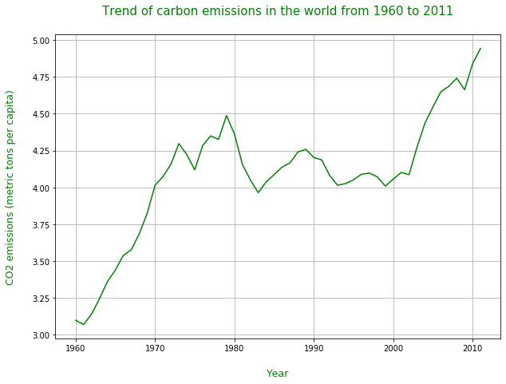

```python
#Plot a line graph
plt.figure(figsize=(10,7))
plt.plot(world_co2['Year'],world_co2['Value'], color='green', linestyle='-')
plt.title('Trend of carbon emissions in the world from 1960 to 2011', pad=25, fontsize=15, color='green')
plt.xlabel(xlabel='Year', fontsize=12.5, color='green', labelpad=20)
plt.ylabel(ylabel='CO2 emissions (metric tons per capita)', fontsize=12.5, color='green', labelpad=20)
plt.grid()
plt.autoscale()
plt.show()
```

## 2. Life expectancy at birth (LEB)

Life expectancy at birth reflects the overall mortality level of a population. In this sub-section, we explore the performance of the indicator across the world for two groups; males and females

```python
#Create filter masks to extract life expectancy data for the world
leb_mask1 = regions['Region'].str.contains('^World')
leb_mask2 = regions['IndicatorName'].str.contains('Life expectancy at birth, male')
leb_mask3 = regions['IndicatorName'].str.contains('Life expectancy at birth, female')

#Male data
world_leb_male = regions[leb_mask1 & leb_mask2]

#Female data
world_leb_female = regions[leb_mask1 & leb_mask3]

del world_leb_male['Region']
del world_leb_male['IndicatorName']
del world_leb_female['Region']
del world_leb_female['IndicatorName']
```

```python
#Preview male data
world_leb_male[::10]
```

|  | Year | Value |
| --- | --- | --- |
| 3418 | 1960 | 50.567960 |
| 306835 | 1970 | 57.721799 |
| 1022200 | 1980 | 60.780819 |
| 1895898 | 1990 | 63.361342 |
| 3190160 | 2000 | 65.674487 |
| 4861798 | 2010 | 68.479379 |

```python
#Generate descriptive table statistics
world_leb_male['Value'].describe()
```

```
count    54.000000
mean     61.783261
std       5.020847
min      50.567960
25%      58.861016
50%      62.563687
75%      65.600458
max      69.204544
Name: Value, dtype: float64
```

```python
#Preview female data
world_leb_female[::10]
```

|  | Year | Value |
| --- | --- | --- |
| 3417 | 1960 | 54.495045 |
| 306834 | 1970 | 61.356800 |
| 1022199 | 1980 | 65.147730 |
| 1895897 | 1990 | 67.713937 |
| 3190159 | 2000 | 69.828339 |
| 4861797 | 2010 | 72.553183 |

```python
#Generate descriptive table statistics
world_leb_female['Value'].describe()
```

```
count    54.000000
mean     65.906458
std       5.122163
min      54.495045
25%      62.860177
50%      66.915097
75%      69.764741
max      73.301046
Name: Value, dtype: float64
```

### 2.1 Life expectancy over time

In this sub-section, we explore the trend of life expectancy at birth over time for both males and females and compare the two

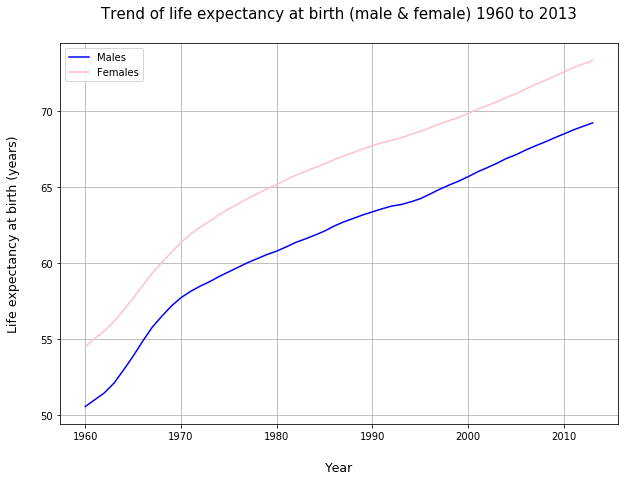

```python
#Plot a line graph
plt.figure(figsize=(10,7))
plt.plot(world_leb_male['Year'], world_leb_male['Value'], linestyle='-', color='blue', label='Males')
plt.plot(world_leb_female['Year'], world_leb_female['Value'], linestyle='-', color='pink', label='Females')
plt.title('Trend of life expectancy at birth (male & female) 1960 to 2013', pad=25, fontsize=15)
plt.xlabel(xlabel='Year', fontsize=12.5, labelpad=20)
plt.ylabel(ylabel='Life expectancy at birth (years)', fontsize=12.5, labelpad=20)
plt.legend(fontsize=10)
plt.grid()
plt.autoscale()
plt.show()
```

**Graph notes:**

- Life expectancy, for both males and females, has increased steadly over time
- Females seem to always have a higher life expectancy than males

We may also intuitively note that the life expectancy of males and females seem to have a strong relationship. We examine this by looking at correlation.

```python
#Determine the correlation of the indicators
np.corrcoef(world_leb_male['Value'], world_leb_female['Value'])
```

```
array([[1.        , 0.99901626],
       [0.99901626, 1.        ]])
```

0.999 is a nearly perfect positive correlation (the highest being 1). That's a very strong relationship. A high positive correlation means that the two features will increase/decrease in parallel to a greater extent. It is important to note however that this does not infer causation.

## 3. Relationship between carbon emissions per capita and life expectancy at birth

In this sub-section, we explore the nature of the relationship that exists between the two indicators.

### 3.1 CO2 emissions & life expectancy (males)

```python
#Check to see if the range of records is equal

print()
print("CO2 emission data: ", min(world_co2['Year']), ' to ', max(world_co2['Year']))
print()
print("Life expectancy data: ", min(world_leb_male['Year']), ' to ', max(world_leb_female['Year']))
```

```
CO2 emission data:  1960  to  2011

Life expectancy data:  1960  to  2013
```

*Life expectancy records seem to be greater by 2, let's fix that*

```python
#Data cleaning

world_leb_male = world_leb_male[world_leb_male['Year'] <= 2011]
```

```python
#Check the correlation of the indicators

np.corrcoef(world_leb_male['Value'], world_co2['Value'])
```

```
array([[1.        , 0.84872372],
       [0.84872372, 1.        ]])
```

0.8487 is a very high positive correlation indicating that there is a strong linear relationship between the two features. Again, we cannot infer from the correlation value alone whether this relationship is causal or not.

Let's think about these results for a minute however. We would have expected, for obvious reasons, that as carbon emissions go up, life expectancy goes down (a negative correlation). However, we are observing the opposite. This could be because the longer people live (life expectancy goes up), the more carbon they will emit (carbon emission per capita goes up) or the relationship might not be causal at all.

Further investigation and expert domain knowledge might be required to comprehensively understand the nature of this relationship.

### 3.2 CO2 emissions & life expectancy (females)

Now, we might have intuitively guessed the results for life expectancy of females.

Given we know that life expectancy of females has a high positive correlation with life expectancy of males, and that life expectancy of males has a high positive correlation with CO2 emissions per capita, we might assume that life expectancy of females has a high positive correlation with CO2 emissions per capita.

However, it is important to note that correlation is not necessarily transitive. So let's explore this and see what comes up.

```python
#Data cleaning
world_leb_female = world_leb_female[world_leb_female['Year'] <= 2011]

#Check the correlation of the indicators
np.corrcoef(world_leb_female['Value'], world_co2['Value'])
```

```
array([[1.       , 0.8446923],
       [0.8446923, 1.       ]])
```

### 3.3 Correlation plot

In this sub-section, we visualize the nature of the relationships between the indicators on a scatter plot

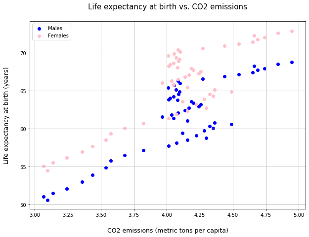

```python
#Create a scatter plot
plt.figure(figsize=(10,7))
plt.scatter(world_co2['Value'], world_leb_male['Value'], color='blue', label='Males')
plt.scatter(world_co2['Value'], world_leb_female['Value'], color='pink', label='Females')
plt.title('Life expectancy at birth vs. CO2 emissions', pad=25, fontsize=15)
plt.xlabel(xlabel='CO2 emissions (metric tons per capita)', fontsize=12.5, labelpad=20)
plt.ylabel(ylabel='Life expectancy at birth (years)', fontsize=12.5, labelpad=20)
plt.legend(fontsize=10)
plt.grid()
plt.autoscale()
plt.show()
```

# Section B: Exploring hospital beds (per 1000 people) across income groups

In this section, we explore income group specific data for the hospital beds (per 1000 people) indicator. We look at trends over time to see how the indicator performs across income groups.

The indicator is a hospital bed to population ratio. The World Health Organization's recommended standard is 5 beds per 1,000 population

```python
#Extract income groups
groups = income_groups['IncomeGroup'].unique().tolist()
del groups[1:4]

#Create filter masks to extract hospital beds data for income groups
beds_mask = income_groups['IndicatorName'].str.contains('Hospital beds')
hospital_beds = income_groups[beds_mask]
del hospital_beds['IndicatorName']

#View the income groups
print('Income groups: ', groups)

#View some sections of the hopital beds data
hospital_beds[::10]
```

```
Income groups:  ['High income', 'Low income', 'Lower middle income', 'Middle income', 'Upper middle income']
```

|  | IncomeGroup | Year | Value |
| --- | --- | --- | --- |
| 1336 | High income: OECD | 1960 | 9.105600 |
| 642839 | Low & middle income | 1975 | 1.548513 |
| 1097922 | Low & middle income | 1981 | 2.055736 |
| 1444497 | Upper middle income | 1985 | 2.833715 |
| 1885667 | High income: nonOECD | 1990 | 9.338487 |
| 2006646 | Lower middle income | 1991 | 1.504036 |
| 2250536 | Upper middle income | 1993 | 2.920460 |
| 2636097 | Upper middle income | 1996 | 2.716395 |
| 3177305 | High income | 2000 | 6.952361 |
| 3487038 | Lower middle income | 2002 | 0.756904 |
| 3951098 | High income: OECD | 2005 | 6.056636 |
| 4667486 | High income | 2009 | 5.567848 |

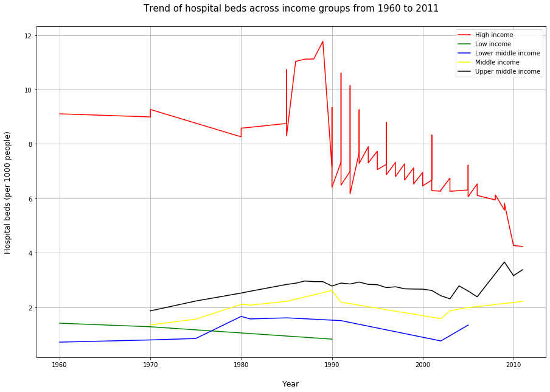

```python
#Plot a line graph
colors = ['red', 'green', 'blue', 'yellow', 'black']
plt.figure(figsize=(15,10))

for group,color in zip(groups,colors):

    mask = hospital_beds['IncomeGroup'].str.contains(group)
    data = hospital_beds[mask]
    plt.plot(data['Year'], data['Value'], linestyle='-', color=color, label=group)

plt.title('Trend of hospital beds across income groups from 1960 to 2011', pad=25, fontsize=15)
plt.xlabel(xlabel='Year', fontsize=12.5, labelpad=20)
plt.ylabel(ylabel='Hospital beds (per 1000 people)', fontsize=12.5, labelpad=20)
plt.legend(fontsize=10)
plt.grid()
plt.autoscale()
plt.show()
```

### Income group definitions:

- High-income economies are those in which 2014 GNI per capita was USD 12,736 or more
- Upper-middle-income economies are those in which 2014 GNI per capita was between USD 4,126 and USD 12,735
- Middle-income economies are those in which 2014 GNI per capita was between USD 1,046 and USD 12,735
- Lower-middle-income economies are those in which 2014 GNI per capita was between USD 1,046 and USD 4,125
- Low-income economies are those in which 2014 GNI per capita was USD 1,045 or less

### Graph notes:

- Data for Low-income economies is only available up to 1990
- Data for Middle-income and Upper-middle-income economies is only available from 1970
- High-income economies seem to have a significantly higher hospital beds to population ratio, although it has dropped over the years
- Other economies still stagger below the WHO's recommended standard

# Section C: Exploring age dependency ratio across regions

In this section, we explore region specific data for the age dependency ratio indicator. We look at how the indicator performed across different regions in the year 2014.

The dependency ratio is an age-population ratio of those typically not in the labor force and those typically in the labor force. It is used to measure the pressure on the productive population.

A high dependency ratio means those of working age, and the overall economy, face a greater burden in supporting the aging population. The global average was 54.36 as of 2018.

```python
#Create filter masks to extract dependecy ratios for the regions
mask1 = regions['IndicatorName'].str.contains('Age dependency ratio \(')
mask2 = regions['Year'].isin([2014])
mask3 = regions['Region'].str.contains('developing only')
dependency = regions[mask1 & mask2 & ~mask3]
del dependency['IndicatorName']
del dependency['Year']

#View some sections of the dependency data
dependency[::5]
```

|  | Region | Value |
| --- | --- | --- |
| 5534308 | Arab World | 61.791896 |
| 5536280 | Europe & Central Asia (all income levels) | 49.425541 |
| 5539823 | Least developed countries: UN classification | 79.962531 |
| 5543701 | Pacific island small states | 64.465132 |

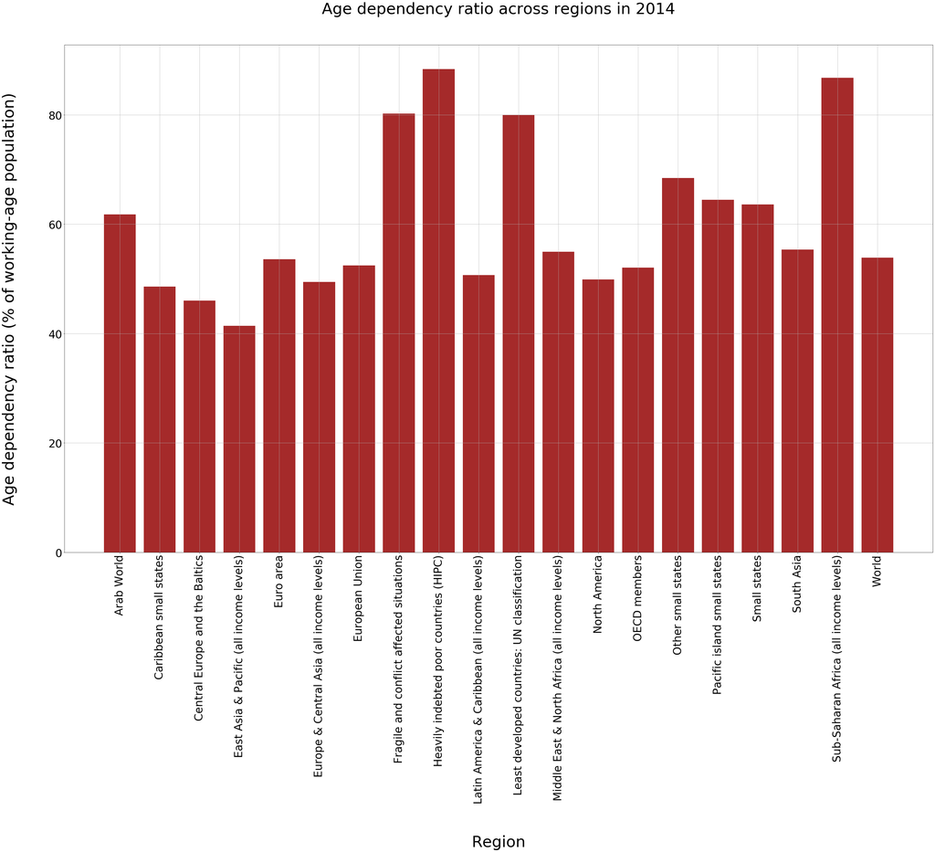

```python
#Plot a bar graph
plt.figure(figsize=(50,30))
plt.bar(dependency['Region'], dependency['Value'], color='brown')
plt.title('Age dependency ratio across regions in 2014', pad=100, fontsize=50)
plt.xlabel(xlabel='Region', fontsize=50, labelpad=100)
plt.ylabel(ylabel='Age dependency ratio (% of working-age population)', fontsize=50, labelpad=100)
plt.tick_params(axis='x', labelrotation = 90, labelsize=35)
plt.tick_params(axis='y', labelsize=35)
plt.grid()
plt.autoscale()
plt.show()
```

### Remarks

- This notebook is an exploration of data and **NOT** a presentation of findings
- This mini-project was undertaken as part of the UCSanDiegoX DSE220x Python for Data Science course (https://www.edx.org/course/python-for-data-science-2)

### Info

Author: Alvin Nahabwe

Date: 6/9/2020 9:38 AM

Email: alvin.n256@gmail.com

[GitHub](https://www.github.com/Alvin-Nahabwe)

[Twitter](https://www.twitter.com/_nahabwe)

[LinkedIn](https://www.linkedin.com/in/alvin-nahabwe)